# *Red Wine Quality - A study in R*

This new variable will be used in the next plots:

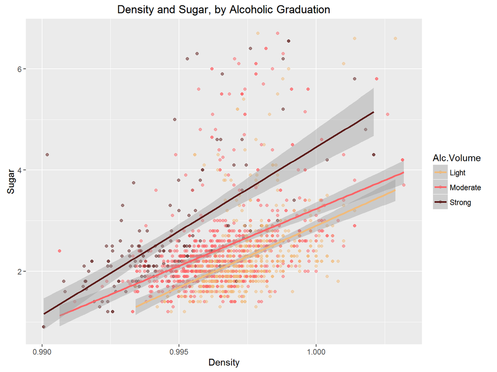

- the more salt, the more density, for every alcohol category.

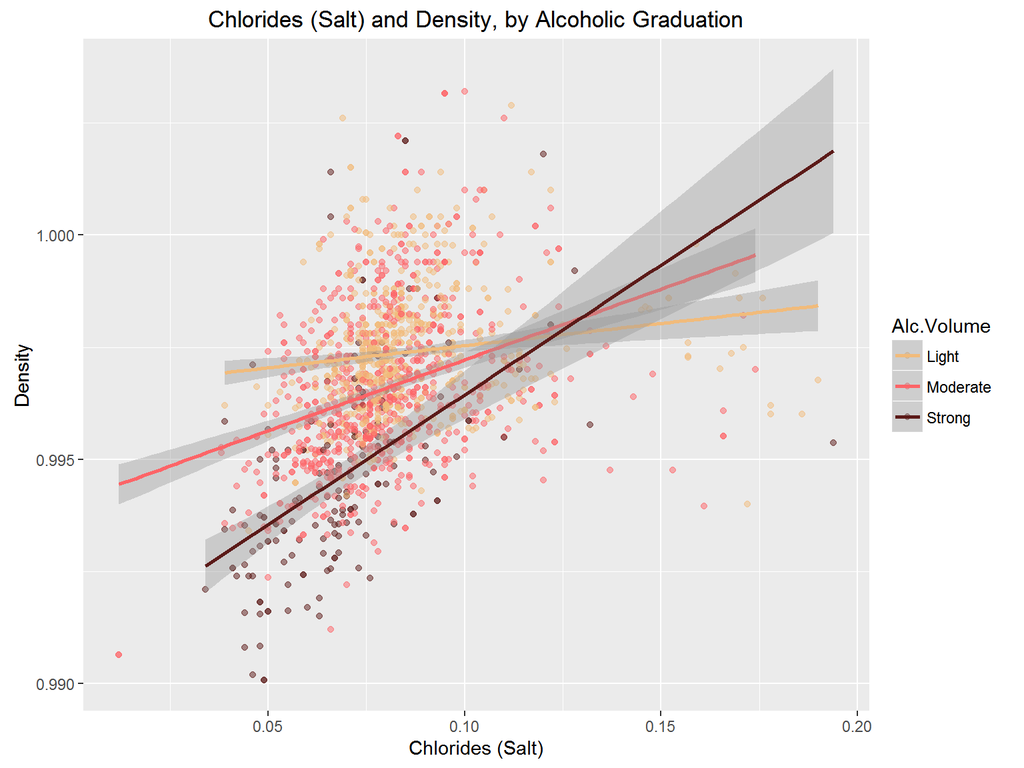

Mixing the Grade and the Alcohol categories:

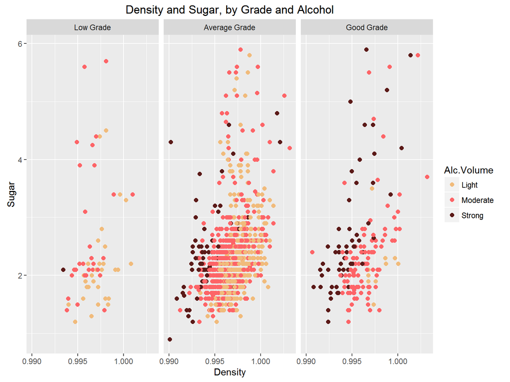

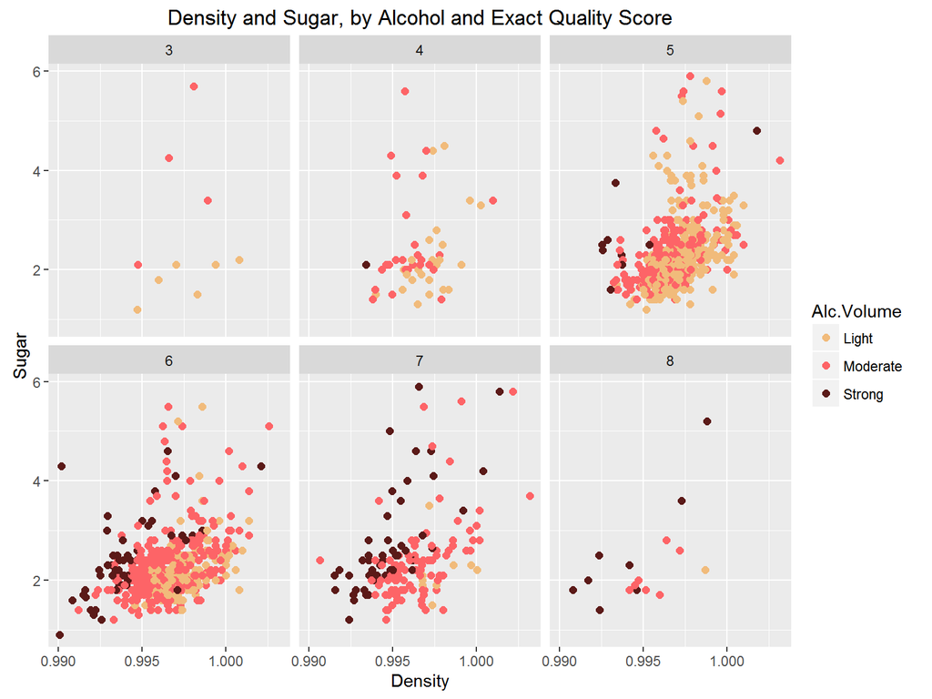

In the nest plot we can see how alcohol affects the quality of the wine, both in numerical values as well as categorized by light, moderate and strong alcohol concentration and low, average and good grade.

The pattern repits itself across the mentioned categories.

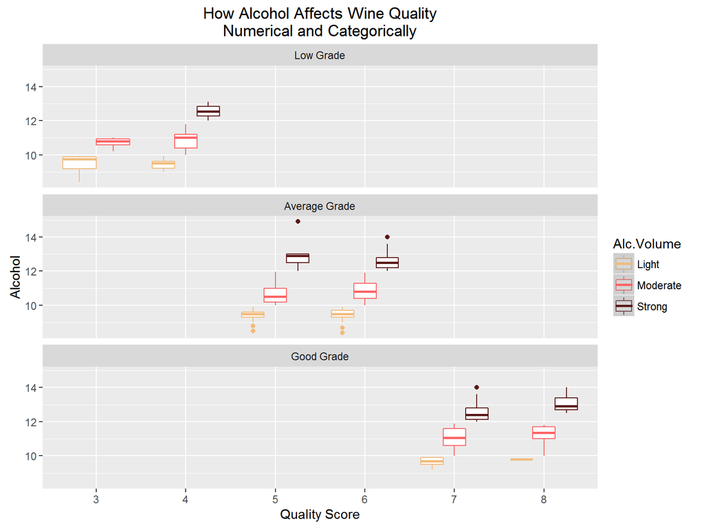

As a bonus, we add a couple of 3D visualizations just to have a taste of the possiblities:

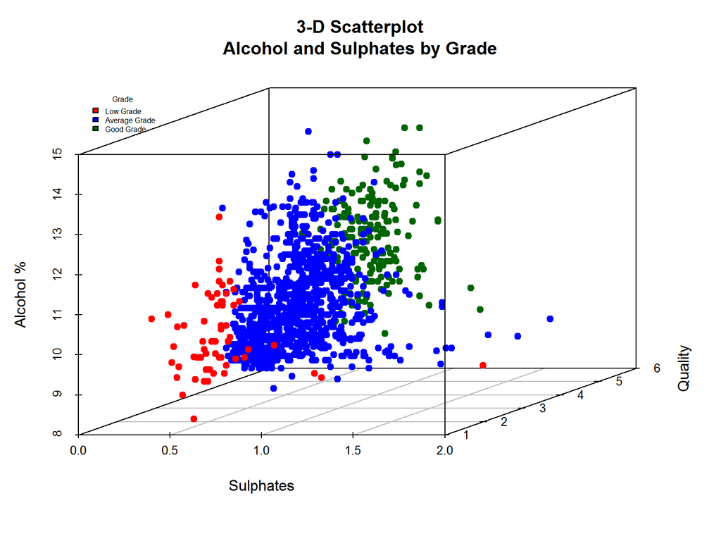

3D mouse-spinning plots: rotate them with your mouse !

Please, try those on your R interpreter:

```
library(Rcmdr)
attach(wine)
plot3d(alcohol,density,grade, main="3D Scatterplot", size = 4)
```

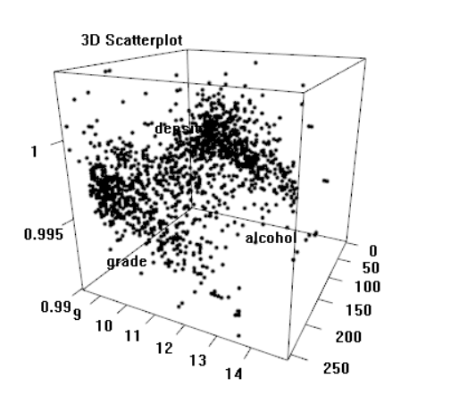

or:

```
library(Rcmdr)
attach(wine)
scatter3d(alcohol,density,chlorides, main="3D Scatterplot", size = 4)
```

[figure not shown]

# *Final Plots and Summary*

### Plot One

This is the simplest plot but nevertheless it gives us a good view of the results of the output variable, the quality score of the wines.

Most of the observations fall into the 5 and 6 quality score, followed by far by 7 quality score. That means than the wines tasted where judged to be of average quality with only a few of them either bad (3, 4 scores) or good/very good (7, 8 scores).

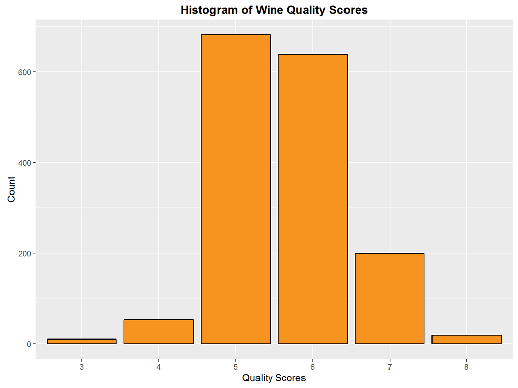

### Plot Two

This plot shows the relationship of the two most positively correlated input variables (alcohol and sulphates) with the output variable quality. The quality scores have been categorized from numerical values (0-10) to Low, Average and Good grades for better understanding.

It is clear that the good graded wines contain more alcohol and sulphates than the average and low graded ones. The main difference between the average and the low graded wines appears to be the concentration of sulphates, being the alcohol level very similar between them.

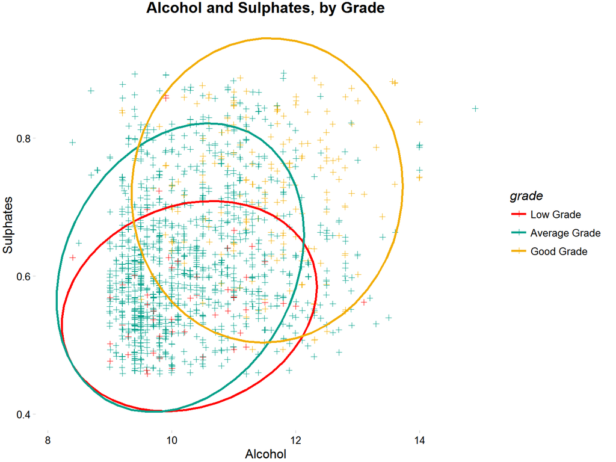

### Plot Three

The third plot is a mix between a “boxplot” and a “violin” that shows the relationship between the most positively correlated input variable (alcohol) and the output variable (quality). The quality variable has been categorized into “Low”, “Average” and “Good” grade because it is better to understand for anyone. The “violin” shapes show the distribution of the data for each category, where the widest zone corresponds to where more data accumulates, while the boxplots show statistical data about the 1st, 2nd, 3rd and 4th Quantiles.

For instance, for the average grade, the data concentrates below the 10% alcohol volume and the mean is almost exactly 10°. Nevertheless, we can find wines with an alcoholic volume even higher than 14°. The low grade wines, although having the mean similar to the average grade (about 10°), show a different distribution, this time more of a real “violin” shape. Now, it is pretty clear that the good graded wines have in average more alcohol, about 11,5° based on the graphic.

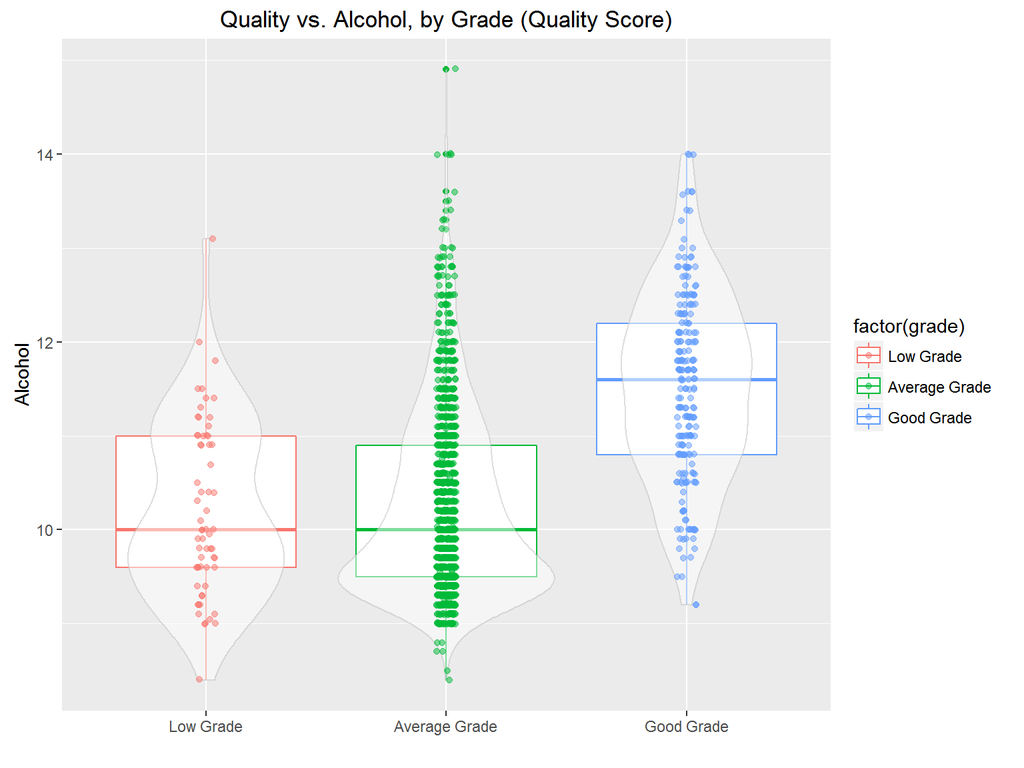

# *Reflection*

Based on this analysis, we have extracted some insights:

- high concentration of wines in the middle ranges of the ranking.
- the more alcohol and sulphates a wine has the better chance to score high in quality.
- other parameters suitable to be directly tasted by the experts like sweetness, acidity and density play a small role in the scoring process.
- pH and acidity variables: while the majority behave as expected, the citric acid defies the general rule (lower pH, higher acidity).

The chemical variables covered in this study can explain a a great deal of the quality, although there are other numerous variables which come into play in order to grade a wine.

The output variable “general quality” -a subjective general scored given by the tasters- is fine but some other indicators are missed. We could think of a quality breakdown into “nose” (smell), taste and color, all of them adding point to the final score. Also, a “blind” vs. “normal” tasting to check if a well known brand can influence the taster decision - bias avoidance.

We might also think of another variables, like barrel wine vs. bottled wine - being the same wine-, professional tasters vs. connoisseurs vs. general wine consumers, and then compare que results. Different grape mixes could also affect the results; the possibilities are endless.

One might think of “price” as a factor of wine quality but we do not agree with that because it could well be the case that the most expensive wines might not be labelled as the best ones, being the price set from other variables like prestige, scarcity of grape in a given year, bad harvest…etc.

# *Resources*

- **Stackoverflow**: http://stackoverflow.com/questions/tagged/r
- **Github**: https://github.com/
- **ggplot2**: http://docs.ggplot2.org/current/
- **The Comprehensive R Archive Network**: https://cran.r-project.org/
- **Statistical tools for high-throughput data analysis**: http://www.sthda.com/english/
- **Sulphites in Wine**: http://www.morethanorganic.com/sulphur-in-the-bottle
- **Wikipedia, pH**: https://en.wikipedia.org/wiki/PH
- **CSS for Knitr**: http://jessachandler.com/2015/06/customize-r-knitr-html-output-easily/